# Flood Zones Analysis

Henry Kanengiser

2022-11-23

The **purpose** of this file is to conduct analyses with the restructured and cleaned datasets as part of of my analysis into NYC’s floodzones. This program builds on the code and permanent files developed in two earlier .Rmd files (a3rs and a3ss). The permanent files read into this program were created in one of those two files.

# Read in files

Note that in R I really only need to work with the non-spatial versions of the files for this analysis.

```r
# Tax-lot level analysis file
tractan <- read_csv(file.path(csv, fil_t))
# Census tract level analysis file
plutoan <- read_csv(file.path(csv, fil_p))
```

Create a few important variables

pluto-level - turn the fz flag vars into 0/1 vars rather than NA/1 vars - estimate counts of units owned and rented based on bldg type

tract-level - borough - turn the fz flag vars into 0/1 vars rather than NA/1 vars

```r
glimpse(plutoan)
```

```
## Rows: 857,020
## Columns: 26
## $ borough     <chr> "MN", "MN", "MN", "MN", "MN", "MN", "MN", "MN", "MN", "MN"…
## $ block       <dbl> 1, 2, 2, 3, 3, 7, 7, 7, 7, 8, 8, 10, 10, 11, 11, 11, 11, 1…
## $ lot         <dbl> 201, 2, 23, 1, 3, 29, 31, 37, 38, 39, 51, 15, 32, 11, 12, …
## $ cd          <dbl> 101, 101, 101, 101, 101, 101, 101, 101, 101, 101, 101, 101…
## $ address     <chr> "1 ELLIS ISLAND", "10 SOUTH STREET", "1 PIER 6", "10 BATTE…
## $ bct2020     <dbl> 1000100, 1000900, 1000900, 1001300, 1000900, 1000900, 1000…
## $ bctcb2020   <dbl> 10001001000, 10009001022, 10009001022, 10013002002, 100090…
## $ ct2010      <dbl> 1.00, 9.00, 9.00, 13.00, 9.00, 9.00, 9.00, 9.00, 9.00, 9.0…
## $ bldg_class  <chr> "Z9", "Y7", "T2", "Q1", "Q1", "P7", "K4", "P7", "S9", "H3"…
## $ bbl         <dbl> 1000010201, 1000020002, 1000020023, 1000030001, 1000030003…
## $ units_res   <dbl> 0, 0, 0, 0, 0, 0, 2, 0, 3, 0, 0, 0, 2, 0, 1, 0, NA, 0, 0, …
## $ year_built  <dbl> 1900, 1900, 1987, 1951, 1951, 1828, 1883, 1831, 1830, 1950…
## $ in_mp       <dbl> 1, 1, 1, 1, 1, 1, 1, 1, 1, 1, 1, 1, 1, 1, 1, 1, 1, 1, 1, 1…
## $ fz50_500y   <dbl> 1, 1, 1, 1, 1, 1, 1, 1, NA, 1, NA, NA, 1, 1, 1, 1, NA, 1, …
## $ fz20_100y   <dbl> 1, 1, 1, 1, 1, 1, 1, 1, NA, 1, NA, NA, 1, 1, 1, 1, NA, NA,…
## $ fz50_100y   <dbl> 1, 1, 1, 1, 1, 1, 1, 1, NA, 1, NA, NA, 1, 1, 1, 1, NA, NA,…
## $ fp_cat      <chr> "2020_100y", "2020_100y", "2020_100y", "2020_100y", "2020_…
## $ in_fz       <dbl> 1, 1, 1, 1, 1, 1, 1, 1, NA, 1, NA, NA, 1, 1, 1, 1, NA, 1, …
## $ bldgtype    <chr> NA, NA, NA, NA, NA, NA, NA, NA, "multiple unit", NA, NA, N…
## $ res_flag    <dbl> 0, 0, 0, 0, 0, 0, 0, 0, 1, 0, 0, 0, 0, 0, 0, 0, 0, 0, 0, 0…
## $ year_cat    <chr> "before 1960", "before 1960", "1980 - 1999", "before 1960"…
## $ development <chr> NA, NA, NA, NA, NA, NA, NA, NA, NA, NA, NA, NA, NA, NA, NA…
## $ nycha       <dbl> NA, NA, NA, NA, NA, NA, NA, NA, NA, NA, NA, NA, NA, NA, NA…
## $ rs2020      <dbl> NA, NA, NA, NA, NA, NA, NA, NA, NA, NA, NA, NA, NA, NA, NA…
## $ unitsres    <dbl> NA, NA, NA, NA, NA, NA, NA, NA, NA, NA, NA, NA, NA, NA, NA…
## $ in_rs       <dbl> NA, NA, NA, NA, NA, NA, NA, NA, NA, NA, NA, NA, NA, NA, NA…
```

```r
plutoan2 <- plutoan %>%
  mutate(fz20_100y = replace_na(fz20_100y, 0),
         fz50_100y = replace_na(fz50_100y, 0),
         fz50_500y = replace_na(fz50_500y, 0),
         nycha = replace_na(nycha, 0),
         units_own = case_when(
          bldgtype == "single family" ~ units_res,
          bldgtype == "multiple unit" ~ 1,
          bldgtype == "condo" ~ units_res,
          bldgtype == "coop" ~ units_res
    ),
        units_rent = case_when(
          bldgtype %in% c("single family", "condo", "coop") ~ 0,
          bldgtype == "multiple unit" ~ units_res - 1
     ))

#Check creation of units_own and units_rent
# Check var creation
plutoan2 %>%
  filter(res_flag == 1) %>%
  summarise(units_res = sum(units_res, na.rm = TRUE),
            units_own = sum(units_own, na.rm = TRUE),
            units_rent = sum(units_rent, na.rm = TRUE))
```

| units_res | units_own | units_rent |
| --- | --- | --- |
| 3314179 | 1308049 | 2006130 |

```r
plutoan2 %>%
  count(res_flag, bldgtype, units_res, units_own, units_rent) %>%
  slice_sample(n=30) %>%
  arrange(desc(res_flag), bldgtype, units_res)
```

| res_flag | bldgtype | units_res | units_own | units_rent | n |
| --- | --- | --- | --- | --- | --- |
| 1 | condo | 7 | 7 | 0 | 149 |
| 1 | condo | 30 | 30 | 0 | 33 |
| 1 | condo | 82 | 82 | 0 | 2 |
| 1 | condo | 135 | 135 | 0 | 2 |
| 1 | condo | 288 | 288 | 0 | 1 |
| 1 | coop | 24 | 24 | 0 | 133 |
| 1 | coop | 91 | 91 | 0 | 11 |
| 1 | coop | 138 | 138 | 0 | 6 |
| 1 | coop | 290 | 290 | 0 | 1 |
| 1 | coop | 1225 | 1225 | 0 | 1 |

[output cut: 20 more lines]

```r
glimpse(tractan)
```

```
## Rows: 2,328
## Columns: 55
## $ name        <chr> "Census Tract 127.01, Bronx County, New York", "Census Tra…
## $ mhhinc      <dbl> 38000, 28083, 30417, 30923, 31083, 48654, 29068, 39875, 52…
## $ poptotl     <dbl> 1968, 6039, 5363, 7524, 6652, 2456, 3710, 4293, 3474, 3600…
## $ popownr     <dbl> 352, 685, 288, 580, 241, 912, 187, 98, 1100, 449, 644, 962…
## $ poprntr     <dbl> 1616, 5354, 5075, 6944, 6411, 1544, 3523, 4195, 2374, 3151…
## $ mhhincm     <dbl> 13393, 20379, 5132, 18890, 7336, 18731, 2672, 15698, 22461…
## $ popttlm     <dbl> 484, 1436, 1159, 1062, 1062, 611, 852, 889, 773, 763, 341,…
## $ popwnrm     <dbl> 184, 383, 228, 534, 271, 465, 141, 115, 413, 239, 238, 304…
## $ pprntrm     <dbl> 502, 1417, 1167, 985, 1027, 423, 853, 886, 802, 766, 261, …
## $ geoid       <dbl> 36005012701, 36005037300, 36005011900, 36005039100, 360050…
## $ poptot      <dbl> 2184, 6117, 5703, 7210, 6826, 3277, 3726, 4078, 3752, 4126…
## $ pophis      <dbl> 1567, 3904, 4008, 5414, 4889, 1587, 2592, 3005, 1250, 3089…
## $ popnhis     <dbl> 617, 2213, 1695, 1796, 1937, 1690, 1134, 1073, 2502, 1037,…
```

[output cut: 42 more lines]

```r
tractan2 <- tractan %>%
  mutate(borocode = substr(bct2020, 1, 1),
         borough = case_when(
           borocode == "1" ~ "MN",
           borocode == "2" ~ "BX",
           borocode == "3" ~ "BK",
           borocode == "4" ~ "QN",
           borocode == "5" ~ "SI"
         ),
         fzr20_100y = replace_na(fzr20_100y, 0),
         fzr50_100y = replace_na(fzr50_100y, 0),
         fzr50_500y = replace_na(fzr50_500y, 0)
         )

# Check creation of borocode and borough
tractan2 %>% count(borocode, borough)
```

| borocode | borough | n |
| --- | --- | --- |
| 1 | MN | 310 |
| 2 | BX | 361 |
| 3 | BK | 805 |
| 4 | QN | 725 |
| 5 | SI | 126 |
| NA | NA | 1 |

```r
tractan2 %>% slice_sample(n=20) %>% select(bct2020, borocode, borough)
```

| bct2020 | borocode | borough |
| --- | --- | --- |
| 1007700 | 1 | MN |
| 4024500 | 4 | QN |
| 4109900 | 4 | QN |
| 4084902 | 4 | QN |
| 4074100 | 4 | QN |
| 1019000 | 1 | MN |
| 3010601 | 3 | BK |
| 3020600 | 3 | BK |
| 2005600 | 2 | BX |
| 3012801 | 3 | BK |

[output cut: 10 more lines]

# Primary Question

**Primary research question: What are the trends in housing types in New York City’s current and future flood zones, and who lives in that housing?**

### How many rental units versus owner-occupied?

MapPLUTO doesn’t break down units by rental versus owner-occupied, so there are two ways to try to answer this:

**Tax-lot level**

- Start with counts of residential type in the different flood zones (# and as % of entire city)

```r
#Use map() to run the same frequency for all three flood zone vars

vars <- c("fz20_100y", "fz50_100y", "fz50_500y")

countpct <- function(var) {
  plutoan2 %>%
    filter(res_flag == 1) %>%
    group_by({{var}} := eval(as.name(paste(var)))) %>%
    summarise(count := n(),
              pct := count / nrow(.)) %>%
    ungroup() %>%
    adorn_totals("row")
}

map(vars, countpct)
```

```
## [[1]]
##  fz20_100y  count        pct
##          0 689090 0.92198164
##          1  58311 0.07801836
##      Total 747401 1.00000000
##
## [[2]]
##  fz50_100y  count        pct
##          0 673264 0.90080693
##          1  74137 0.09919307
##      Total 747401 1.00000000
##
## [[3]]
##  fz50_500y  count       pct
##          0 639037 0.8550122
##          1 108364 0.1449878
##      Total 747401 1.0000000
```

- Using the residential type and number of residential units variables (for multi-family housing, assume that 1 unit is owner-occupied to be conservative)

```r
vars <- c("fz20_100y", "fz50_100y", "fz50_500y")

unit_ctpct <- function(var){
  plutoan2 %>%
    group_by({{var}} := eval(as.name(paste(var)))) %>%
    summarise(units_own = sum(units_own, na.rm = TRUE),
              units_rent = sum(units_rent, na.rm = TRUE),
              units_own_pct = units_own / sum(plutoan2$units_own, na.rm = TRUE),
              units_rent_pct = units_rent / sum(plutoan2$units_rent, na.rm = TRUE)) %>%
    ungroup() %>%
    adorn_totals("row")
}

map(vars, unit_ctpct)
```

```
## [[1]]
##  fz20_100y units_own units_rent units_own_pct units_rent_pct
##          0   1158215    1813747     0.8854523     0.90410243
##          1    149834     192383     0.1145477     0.09589757
##      Total   1308049    2006130     1.0000000     1.00000000
##
## [[2]]
##  fz50_100y units_own units_rent units_own_pct units_rent_pct
##          0   1127247    1765170     0.8617773      0.8798881
##          1    180802     240960     0.1382227      0.1201119
##      Total   1308049    2006130     1.0000000      1.0000000
##
## [[3]]
##  fz50_500y units_own units_rent units_own_pct units_rent_pct
##          0   1078272    1670776     0.8243361      0.8328354
##          1    229777     335354     0.1756639      0.1671646
##      Total   1308049    2006130     1.0000000      1.0000000
```

Census tract level - Use ACS responses at the census tract level, which gives an estimate of the area even if it’s not exactly lined up with the flood zones

```r
vars <- c("fzr20_100y", "fzr50_100y", "fzr50_500y")

tract_ctpct <- function(var){
  tractan2 %>%
    group_by({{var}} := eval(as.name(paste(var)))) %>%
    summarise(n_own = sum(popownr, na.rm = TRUE),
            n_rent = sum(poprntr, na.rm = TRUE),
            n_tot = sum(poptotl, na.rm = TRUE)) %>%
    adorn_totals("row") %>%
    mutate(p_own = n_own / n_tot,
           p_rent = n_rent / n_tot)
}

map(vars, tract_ctpct)
```

```
## [[1]]
##  fzr20_100y   n_own  n_rent   n_tot     p_own    p_rent
##           0 2317514 4296339 6613853 0.3504030 0.6495970
##           1  634136  948543 1582679 0.4006725 0.5993275
##       Total 2951650 5244882 8196532 0.3601096 0.6398904
##
## [[2]]
##  fzr50_100y   n_own  n_rent   n_tot     p_own    p_rent
##           0 2205216 4066806 6272022 0.3515957 0.6484043
##           1  746434 1178076 1924510 0.3878566 0.6121434
##       Total 2951650 5244882 8196532 0.3601096 0.6398904
##
## [[3]]
##  fzr50_500y   n_own  n_rent   n_tot     p_own    p_rent
##           0 2000168 3748575 5748743 0.3479314 0.6520686
##           1  951482 1496307 2447789 0.3887108 0.6112892
##       Total 2951650 5244882 8196532 0.3601096 0.6398904
```

### Digging into this

Break these rates down by borough - which borough has most of the residential units in the flood zone? (1 borough ÷ 5 boroughs)

In the future, Brooklyn will have the majority of the buildings in the flood zone (50%, compared to 29% outside the flood zone in the 2050 500-year storm), but for now it hashas a more proportional amount that’s still the plurality

```r
vars <- c("fz20_100y", "fz50_100y", "fz50_500y")

countpct_boro <- function(var) {
  plutoan2 %>%
    filter(res_flag == 1) %>%
    group_by({{var}} := eval(as.name(paste(var))), borough) %>%
    summarise(count := n(),
              .groups = "keep") %>%
    ungroup() %>%
    adorn_totals("row", fill = "NYC") %>%
    group_by({{var}} := eval(as.name(paste(var)))) %>%
    mutate(pct = count / sum(count))

  # # GROUPED BAR PLOT (uncomment if you want to show that)
  # plutoan2 %>%
  #   filter(res_flag == 1) %>%
  #   group_by({{var}} := eval(as.name(paste(var))), borough) %>%
  #   summarise(count := n(),
  #             .groups = "keep") %>%
  #   ungroup() %>%
  #   adorn_totals("row", fill = "NYC") %>%
  #   group_by({{var}} := eval(as.name(paste(var)))) %>%
  #   mutate(pct = count / sum(count)) %>%
  #   ggplot() +
  #   aes(fill = eval(as.name(paste(var))), x = borough, y = pct) +
  #   geom_col(position = "dodge")
}

map(vars, countpct_boro)
```

```
## [[1]]
## # A tibble: 11 × 4
## # Groups:   fz20_100y [3]
##    fz20_100y borough  count    pct
##    <chr>     <chr>    <int>  <dbl>
##  1 0         BK      215829 0.313
##  2 0         BX       71587 0.104
##  3 0         MN       27033 0.0392
##  4 0         QN      274186 0.398
##  5 0         SI      100455 0.146
##  6 1         BK       26216 0.450
##  7 1         BX        2891 0.0496
##  8 1         MN        1951 0.0335
##  9 1         QN       17514 0.300
## 10 1         SI        9739 0.167
## 11 Total     NYC     747401 1
##
## [[2]]
## # A tibble: 11 × 4
## # Groups:   fz50_100y [3]
##    fz50_100y borough  count    pct
##    <chr>     <chr>    <int>  <dbl>
##  1 0         BK      206516 0.307
##  2 0         BX       70635 0.105
##  3 0         MN       26373 0.0392
##  4 0         QN      270921 0.402
##  5 0         SI       98819 0.147
##  6 1         BK       35529 0.479
##  7 1         BX        3843 0.0518
##  8 1         MN        2611 0.0352
##  9 1         QN       20779 0.280
## 10 1         SI       11375 0.153
## 11 Total     NYC     747401 1
##
## [[3]]
## # A tibble: 11 × 4
## # Groups:   fz50_500y [3]
##    fz50_500y borough  count    pct
##    <chr>     <chr>    <int>  <dbl>
##  1 0         BK      187147 0.293
##  2 0         BX       65900 0.103
##  3 0         MN       24727 0.0387
##  4 0         QN      266062 0.416
##  5 0         SI       95201 0.149
##  6 1         BK       54898 0.507
##  7 1         BX        8578 0.0792
##  8 1         MN        4257 0.0393
##  9 1         QN       25638 0.237
## 10 1         SI       14993 0.138
## 11 Total     NYC     747401 1
```

```
--    has the most owner-occupied versus renter?
```

```r
vars <- c("fz20_100y", "fz50_100y", "fz50_500y")

unit_ctpct_boro <- function(var){
  plutoan2 %>%
    filter(res_flag == 1) %>%
    group_by({{var}} := eval(as.name(paste(var))), borough) %>%
    summarise(n_own = sum(units_own, na.rm = TRUE),
              n_rent = sum(units_rent, na.rm = TRUE),
              n_tot = sum(units_res * res_flag, na.rm = TRUE),
              .groups = "keep") %>%
    ungroup() %>%
    adorn_totals("row", fill = "NYC") %>%
    group_by({{var}} := eval(as.name(paste(var)))) %>%
    mutate(p_own = n_own / sum(n_own),
           p_rent = n_rent / sum(n_rent))
}

map(vars, unit_ctpct_boro)
```

```
## [[1]]
## # A tibble: 11 × 7
## # Groups:   fz20_100y [3]
##    fz20_100y borough   n_own  n_rent   n_tot  p_own p_rent
##    <chr>     <chr>     <dbl>   <dbl>   <dbl>  <dbl>  <dbl>
##  1 0         BK       307544  580715  888259 0.266  0.320
##  2 0         BX       122221  388261  510482 0.106  0.214
##  3 0         MN       218576  451014  669590 0.189  0.249
##  4 0         QN       399915  345667  745582 0.345  0.191
##  5 0         SI       109959   48090  158049 0.0949 0.0265
##  6 1         BK        51168   61682  112850 0.341  0.321
##  7 1         BX        20924    7080   28004 0.140  0.0368
##  8 1         MN        31957   79797  111754 0.213  0.415
##  9 1         QN        34810   39119   73929 0.232  0.203
## 10 1         SI        10975    4705   15680 0.0732 0.0245
## 11 Total     NYC     1308049 2006130 3314179 1      1
##
## [[2]]
## # A tibble: 11 × 7
## # Groups:   fz50_100y [3]
##    fz50_100y borough   n_own  n_rent   n_tot  p_own p_rent
##    <chr>     <chr>     <dbl>   <dbl>   <dbl>  <dbl>  <dbl>
##  1 0         BK       292908  558712  851620 0.260  0.317
##  2 0         BX       119179  382509  501688 0.106  0.217
##  3 0         MN       213776  437427  651203 0.190  0.248
##  4 0         QN       393215  339226  732441 0.349  0.192
##  5 0         SI       108169   47296  155465 0.0960 0.0268
##  6 1         BK        65804   83685  149489 0.364  0.347
##  7 1         BX        23966   12832   36798 0.133  0.0533
##  8 1         MN        36757   93384  130141 0.203  0.388
##  9 1         QN        41510   45560   87070 0.230  0.189
## 10 1         SI        12765    5499   18264 0.0706 0.0228
## 11 Total     NYC     1308049 2006130 3314179 1      1
##
## [[3]]
## # A tibble: 11 × 7
## # Groups:   fz50_500y [3]
##    fz50_500y borough   n_own  n_rent   n_tot  p_own p_rent
##    <chr>     <chr>     <dbl>   <dbl>   <dbl>  <dbl>  <dbl>
##  1 0         BK       269491  520913  790404 0.250  0.312
##  2 0         BX       112777  366715  479492 0.105  0.219
##  3 0         MN       204340  406646  610986 0.190  0.243
##  4 0         QN       387348  332259  719607 0.359  0.199
##  5 0         SI       104316   44243  148559 0.0967 0.0265
##  6 1         BK        89221  121484  210705 0.388  0.362
##  7 1         BX        30368   28626   58994 0.132  0.0854
##  8 1         MN        46193  124165  170358 0.201  0.370
##  9 1         QN        47377   52527   99904 0.206  0.157
## 10 1         SI        16618    8552   25170 0.0723 0.0255
## 11 Total     NYC     1308049 2006130 3314179 1      1
```

- which borough has the highest % of its residential units in the flood zone (in_fz ÷ total units in borough)

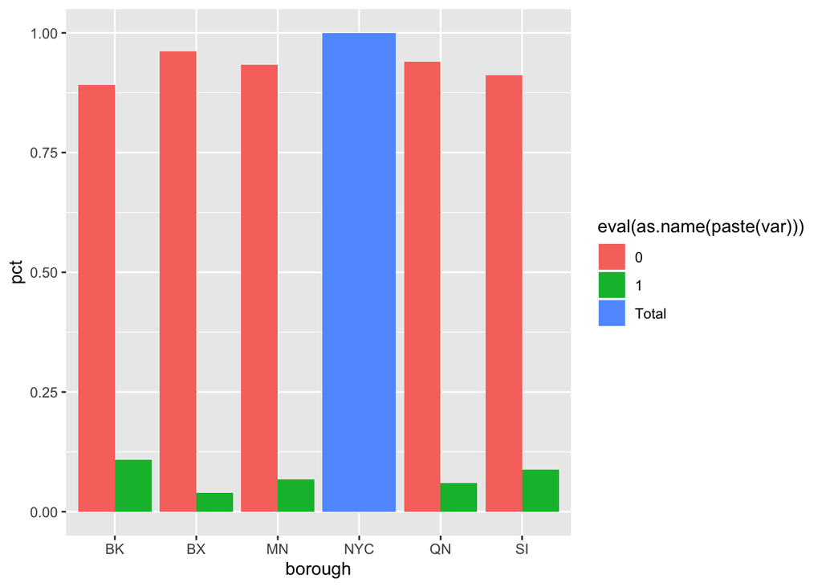

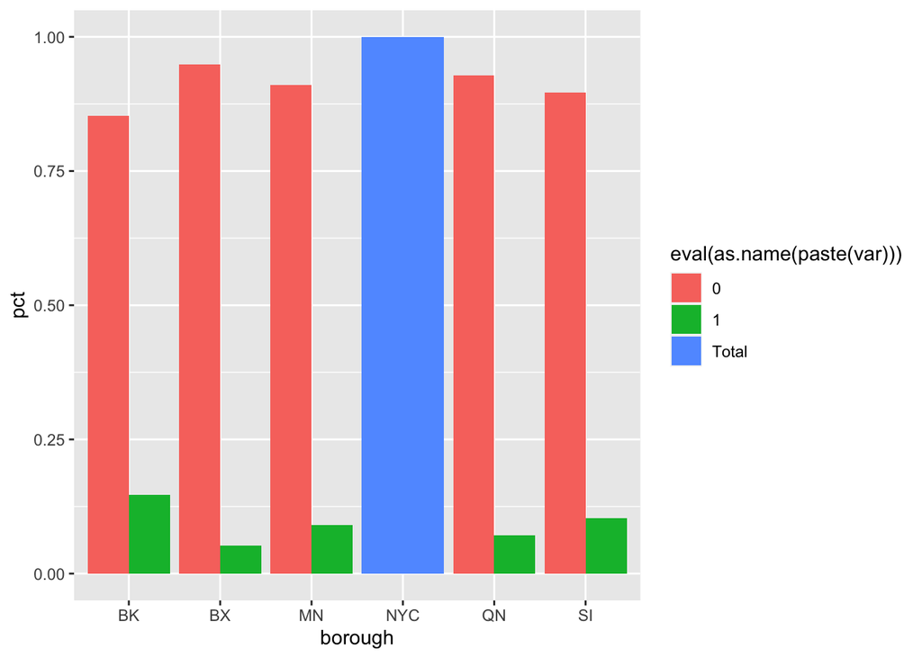

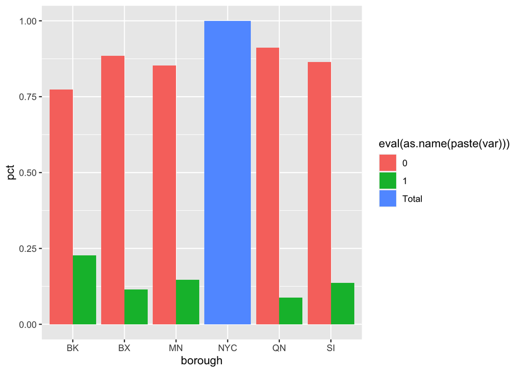

[output not shown]

```r
vars <- c("fz20_100y", "fz50_100y", "fz50_500y")

countpct_boro <- function(var) {
  plutoan2 %>%
    filter(res_flag == 1) %>%
    group_by({{var}} := eval(as.name(paste(var))), borough) %>%
    summarise(count := n(),
              .groups = "keep") %>%
    ungroup() %>%
    adorn_totals("row", fill = "NYC") %>%
    group_by(borough) %>%
    mutate(pct = count / sum(count))

  # # GROUPED BAR PLOT (uncomment if you want to show that)
  plutoan2 %>%
    filter(res_flag == 1) %>%
    group_by({{var}} := eval(as.name(paste(var))), borough) %>%
    summarise(count := n(),
              .groups = "keep") %>%
    ungroup() %>%
    adorn_totals("row", fill = "NYC") %>%
    group_by(borough) %>%
    mutate(pct = count / sum(count)) %>%
    ggplot() +
    aes(fill = eval(as.name(paste(var))), x = borough, y = pct) +
    geom_col(position = "dodge")
}

map(vars, countpct_boro)
```

```r
vars <- c("fz20_100y", "fz50_100y", "fz50_500y")

unit_ctpct_boro <- function(var){
  plutoan2 %>%
    filter(res_flag == 1) %>%
    group_by({{var}} := eval(as.name(paste(var))), borough) %>%
    summarise(n_own = sum(units_own, na.rm = TRUE),
              n_rent = sum(units_rent, na.rm = TRUE),
              n_tot = sum(units_res * res_flag, na.rm = TRUE),
              .groups = "keep") %>%
    ungroup() %>%
    adorn_totals("row", fill = "NYC") %>%
    group_by(borough) %>%
    mutate(p_own = n_own / sum(n_own),
           p_rent = n_rent / sum(n_rent))
}

map(vars, unit_ctpct_boro)
```

```
## [[1]]
## # A tibble: 11 × 7
## # Groups:   borough [6]
##    fz20_100y borough   n_own  n_rent   n_tot  p_own p_rent
##    <chr>     <chr>     <dbl>   <dbl>   <dbl>  <dbl>  <dbl>
##  1 0         BK       307544  580715  888259 0.857  0.904
##  2 0         BX       122221  388261  510482 0.854  0.982
##  3 0         MN       218576  451014  669590 0.872  0.850
##  4 0         QN       399915  345667  745582 0.920  0.898
##  5 0         SI       109959   48090  158049 0.909  0.911
##  6 1         BK        51168   61682  112850 0.143  0.0960
##  7 1         BX        20924    7080   28004 0.146  0.0179
##  8 1         MN        31957   79797  111754 0.128  0.150
##  9 1         QN        34810   39119   73929 0.0801 0.102
## 10 1         SI        10975    4705   15680 0.0908 0.0891
## 11 Total     NYC     1308049 2006130 3314179 1      1
##
## [[2]]
## # A tibble: 11 × 7
## # Groups:   borough [6]
##    fz50_100y borough   n_own  n_rent   n_tot  p_own p_rent
##    <chr>     <chr>     <dbl>   <dbl>   <dbl>  <dbl>  <dbl>
##  1 0         BK       292908  558712  851620 0.817  0.870
##  2 0         BX       119179  382509  501688 0.833  0.968
##  3 0         MN       213776  437427  651203 0.853  0.824
##  4 0         QN       393215  339226  732441 0.905  0.882
##  5 0         SI       108169   47296  155465 0.894  0.896
##  6 1         BK        65804   83685  149489 0.183  0.130
##  7 1         BX        23966   12832   36798 0.167  0.0325
##  8 1         MN        36757   93384  130141 0.147  0.176
##  9 1         QN        41510   45560   87070 0.0955 0.118
## 10 1         SI        12765    5499   18264 0.106  0.104
## 11 Total     NYC     1308049 2006130 3314179 1      1
##
## [[3]]
## # A tibble: 11 × 7
## # Groups:   borough [6]
##    fz50_500y borough   n_own  n_rent   n_tot p_own p_rent
##    <chr>     <chr>     <dbl>   <dbl>   <dbl> <dbl>  <dbl>
##  1 0         BK       269491  520913  790404 0.751 0.811
##  2 0         BX       112777  366715  479492 0.788 0.928
##  3 0         MN       204340  406646  610986 0.816 0.766
##  4 0         QN       387348  332259  719607 0.891 0.863
##  5 0         SI       104316   44243  148559 0.863 0.838
##  6 1         BK        89221  121484  210705 0.249 0.189
##  7 1         BX        30368   28626   58994 0.212 0.0724
##  8 1         MN        46193  124165  170358 0.184 0.234
##  9 1         QN        47377   52527   99904 0.109 0.137
## 10 1         SI        16618    8552   25170 0.137 0.162
## 11 Total     NYC     1308049 2006130 3314179 1     1
```

# Secondary research question

### Additional considerations related to housing

##### Age

- age: how many old buildings are in the flood zone vs the rest of the city?

```r
vars <- c("fz20_100y", "fz50_100y", "fz50_500y")

countpct_age <- function(var) {
  plutoan2 %>%
    filter(res_flag == 1) %>%
    group_by({{var}} := eval(as.name(paste(var))), year_cat) %>%
    summarise(count := n(),
              .groups = "keep") %>%
    ungroup() %>%
    adorn_totals("row", fill = "ALL") %>%
    group_by({{var}} := eval(as.name(paste(var)))) %>%
    mutate(pct = count / sum(count))
}

map(vars, countpct_age)
```

```
## [[1]]
## # A tibble: 11 × 4
## # Groups:   fz20_100y [3]
##    fz20_100y year_cat     count      pct
##    <chr>     <chr>        <int>    <dbl>
##  1 0         1960 - 1979  72639 0.105
##  2 0         1980 - 1999  46028 0.0668
##  3 0         before 1960 522847 0.759
##  4 0         since 2000   47274 0.0686
##  5 0         <NA>           302 0.000438
##  6 1         1960 - 1979  15143 0.260
##  7 1         1980 - 1999   4784 0.0820
##  8 1         before 1960  31433 0.539
##  9 1         since 2000    6898 0.118
## 10 1         <NA>            53 0.000909
## 11 Total     ALL         747401 1
##
## [[2]]
## # A tibble: 11 × 4
## # Groups:   fz50_100y [3]
##    fz50_100y year_cat     count      pct
##    <chr>     <chr>        <int>    <dbl>
##  1 0         1960 - 1979  69102 0.103
##  2 0         1980 - 1999  45121 0.0670
##  3 0         before 1960 513029 0.762
##  4 0         since 2000   45718 0.0679
##  5 0         <NA>           294 0.000437
##  6 1         1960 - 1979  18680 0.252
##  7 1         1980 - 1999   5691 0.0768
##  8 1         before 1960  41251 0.556
##  9 1         since 2000    8454 0.114
## 10 1         <NA>            61 0.000823
## 11 Total     ALL         747401 1
##
## [[3]]
## # A tibble: 11 × 4
## # Groups:   fz50_500y [3]
##    fz50_500y year_cat     count      pct
##    <chr>     <chr>        <int>    <dbl>
##  1 0         1960 - 1979  63128 0.0988
##  2 0         1980 - 1999  43159 0.0675
##  3 0         before 1960 489797 0.766
##  4 0         since 2000   42670 0.0668
##  5 0         <NA>           283 0.000443
##  6 1         1960 - 1979  24654 0.228
##  7 1         1980 - 1999   7653 0.0706
##  8 1         before 1960  64483 0.595
##  9 1         since 2000   11502 0.106
## 10 1         <NA>            72 0.000664
## 11 Total     ALL         747401 1
```

```
--    how many old residential units (owned & rented) are in the flood zone vs. rest of city?
--    what % of old residential units are owned/rented in the flood zone vs. rest of city?
```

```r
vars <- c("fz20_100y", "fz50_100y", "fz50_500y")

unit_ctpct_age <- function(var){
  plutoan2 %>%
    filter(res_flag == 1) %>%
    group_by({{var}} := eval(as.name(paste(var))), year_cat) %>%
    summarise(n_own = sum(units_own, na.rm = TRUE),
              n_rent = sum(units_rent, na.rm = TRUE),
              n_tot = sum(units_res * res_flag, na.rm = TRUE),
              .groups = "keep") %>%
    ungroup() %>%
    adorn_totals("row", fill = "NYC") %>%
    group_by({{var}} := eval(as.name(paste(var)))) %>%
    mutate(p_own = n_own / sum(n_own),
           p_rent = n_rent / sum(n_rent))
}

map(vars, unit_ctpct_age)
```

```
## [[1]]
## # A tibble: 11 × 7
## # Groups:   fz20_100y [3]
##    fz20_100y year_cat      n_own  n_rent   n_tot   p_own   p_rent
##    <chr>     <chr>         <dbl>   <dbl>   <dbl>   <dbl>    <dbl>
##  1 0         1960 - 1979  197037  239221  436258 0.170   0.132
##  2 0         1980 - 1999   64762   77260  142022 0.0559  0.0426
##  3 0         before 1960  805601 1298361 2103962 0.696   0.716
##  4 0         since 2000    81381  197987  279368 0.0703  0.109
##  5 0         <NA>           9434     918   10352 0.00815 0.000506
##  6 1         1960 - 1979   67890   45600  113490 0.453   0.237
##  7 1         1980 - 1999   10153   12471   22624 0.0678  0.0648
##  8 1         before 1960   54090   95904  149994 0.361   0.499
##  9 1         since 2000    16356   37038   53394 0.109   0.193
## 10 1         <NA>           1345    1370    2715 0.00898 0.00712
## 11 Total     NYC         1308049 2006130 3314179 1       1
##
## [[2]]
## # A tibble: 11 × 7
## # Groups:   fz50_100y [3]
##    fz50_100y year_cat      n_own  n_rent   n_tot   p_own   p_rent
##    <chr>     <chr>         <dbl>   <dbl>   <dbl>   <dbl>    <dbl>
##  1 0         1960 - 1979  187239  226760  413999 0.166   0.128
##  2 0         1980 - 1999   63192   75929  139121 0.0561  0.0430
##  3 0         before 1960  790673 1271086 2061759 0.701   0.720
##  4 0         since 2000    76871  190630  267501 0.0682  0.108
##  5 0         <NA>           9272     765   10037 0.00823 0.000433
##  6 1         1960 - 1979   77688   58061  135749 0.430   0.241
##  7 1         1980 - 1999   11723   13802   25525 0.0648  0.0573
##  8 1         before 1960   69018  123179  192197 0.382   0.511
##  9 1         since 2000    20866   44395   65261 0.115   0.184
## 10 1         <NA>           1507    1523    3030 0.00834 0.00632
## 11 Total     NYC         1308049 2006130 3314179 1       1
##
## [[3]]
## # A tibble: 11 × 7
## # Groups:   fz50_500y [3]
##    fz50_500y year_cat      n_own  n_rent   n_tot   p_own   p_rent
##    <chr>     <chr>         <dbl>   <dbl>   <dbl>   <dbl>    <dbl>
##  1 0         1960 - 1979  176332  204675  381007 0.164   0.123
##  2 0         1980 - 1999   60220   71958  132178 0.0558  0.0431
##  3 0         before 1960  760862 1215275 1976137 0.706   0.727
##  4 0         since 2000    71863  178106  249969 0.0666  0.107
##  5 0         <NA>           8995     762    9757 0.00834 0.000456
##  6 1         1960 - 1979   88595   80146  168741 0.386   0.239
##  7 1         1980 - 1999   14695   17773   32468 0.0640  0.0530
##  8 1         before 1960   98829  178990  277819 0.430   0.534
##  9 1         since 2000    25874   56919   82793 0.113   0.170
## 10 1         <NA>           1784    1526    3310 0.00776 0.00455
## 11 Total     NYC         1308049 2006130 3314179 1       1
```

```
--    by borough, how many old units are in the flood zone vs. rest of city
--    by borough, what % of old residential units are owned/rented in the flood zone vs. rest of city?
```

```r
vars <- c("fz20_100y", "fz50_100y", "fz50_500y")

unit_ctpct_age <- function(var){
  plutoan2 %>%
    filter(res_flag == 1) %>%
    group_by({{var}} := eval(as.name(paste(var))), year_cat, borough) %>%
    summarise(n_own = sum(units_own, na.rm = TRUE),
              n_rent = sum(units_rent, na.rm = TRUE),
              n_tot = sum(units_res * res_flag, na.rm = TRUE),
              .groups = "keep") %>%
    ungroup() %>%
    adorn_totals("row", fill = "NYC") %>%
    group_by({{var}} := eval(as.name(paste(var))), borough) %>%
    mutate(p_own = round(n_own / sum(n_own), digits = 4),
           p_rent = round(n_rent / sum(n_rent), digits = 4)) %>%
    arrange({{var}}, borough)
}

map(vars, unit_ctpct_age)
```

```
## [[1]]
## # A tibble: 50 × 8
## # Groups:   fz20_100y, borough [11]
##    fz20_100y year_cat    borough  n_own n_rent  n_tot  p_own p_rent
##    <chr>     <chr>       <chr>    <dbl>  <dbl>  <dbl>  <dbl>  <dbl>
##  1 0         1960 - 1979 BK       27549  59041  86590 0.0896 0.102
##  2 0         1980 - 1999 BK       10881  14820  25701 0.0354 0.0255
##  3 0         before 1960 BK      236546 440345 676891 0.769  0.758
##  4 0         since 2000  BK       31397  66300  97697 0.102  0.114
##  5 0         <NA>        BK        1171    209   1380 0.0038 0.0004
##  6 1         1960 - 1979 BK       19735  16769  36504 0.386  0.272
##  7 1         1980 - 1999 BK        2401    988   3389 0.0469 0.016
##  8 1         before 1960 BK       23168  33942  57110 0.453  0.550
##  9 1         since 2000  BK        5411   9965  15376 0.106  0.162
## 10 1         <NA>        BK         453     18    471 0.0089 0.0003
## # … with 40 more rows
##
## [[2]]
## # A tibble: 50 × 8
## # Groups:   fz50_100y, borough [11]
##    fz50_100y year_cat    borough  n_own n_rent  n_tot  p_own p_rent
##    <chr>     <chr>       <chr>    <dbl>  <dbl>  <dbl>  <dbl>  <dbl>
##  1 0         1960 - 1979 BK       22705  51764  74469 0.0775 0.0926
##  2 0         1980 - 1999 BK       10321  14572  24893 0.0352 0.0261
##  3 0         before 1960 BK      229154 428113 657267 0.782  0.766
##  4 0         since 2000  BK       29671  64072  93743 0.101  0.115
##  5 0         <NA>        BK        1057    191   1248 0.0036 0.0003
##  6 1         1960 - 1979 BK       24579  24046  48625 0.374  0.287
##  7 1         1980 - 1999 BK        2961   1236   4197 0.045  0.0148
##  8 1         before 1960 BK       30560  46174  76734 0.464  0.552
##  9 1         since 2000  BK        7137  12193  19330 0.108  0.146
## 10 1         <NA>        BK         567     36    603 0.0086 0.0004
## # … with 40 more rows
##
## [[3]]
## # A tibble: 51 × 8
## # Groups:   fz50_500y, borough [11]
##    fz50_500y year_cat    borough  n_own n_rent  n_tot  p_own p_rent
##    <chr>     <chr>       <chr>    <dbl>  <dbl>  <dbl>  <dbl>  <dbl>
##  1 0         1960 - 1979 BK       19148  40378  59526 0.0711 0.0775
##  2 0         1980 - 1999 BK        9609  13789  23398 0.0357 0.0265
##  3 0         before 1960 BK      212374 406128 618502 0.788  0.780
##  4 0         since 2000  BK       27342  60428  87770 0.102  0.116
##  5 0         <NA>        BK        1018    190   1208 0.0038 0.0004
##  6 1         1960 - 1979 BK       28136  35432  63568 0.315  0.292
##  7 1         1980 - 1999 BK        3673   2019   5692 0.0412 0.0166
##  8 1         before 1960 BK       47340  68159 115499 0.531  0.561
##  9 1         since 2000  BK        9466  15837  25303 0.106  0.130
## 10 1         <NA>        BK         606     37    643 0.0068 0.0003
## # … with 41 more rows
```

### Race and income in the flood zone

- race/ethnicity: what percent of the white/black/hispanic/asian/other population is in the fz?

```r
vars <- c("fzr20_100y", "fzr50_100y", "fzr50_500y")

tract_ctpct_race <- function(var){
  tractan2 %>%
    group_by({{var}} := eval(as.name(paste(var)))) %>%
    summarise(ntot = sum(poptot, na.rm = TRUE),
              nwhit = sum(popwhit, na.rm = TRUE),
              nblck = sum(popblck, na.rm = TRUE),
              nhisp = sum(pophis, na.rm = TRUE),
              nasin = sum(popasin, na.rm = TRUE)
              ) %>%
    ungroup() %>%
    mutate(pwhit = nwhit/sum(nwhit),
           pblck = nblck/sum(nblck),
           phisp = nhisp/sum(nhisp),
           pasin = nasin/sum(nasin)) %>%
    adorn_totals("row")
}

map(vars, tract_ctpct_race)
```

```
## [[1]]
##  fzr20_100y    ntot   nwhit   nblck   nhisp   nasin     pwhit     pblck
##           0 7091280 1996580 1486710 2109769 1129329 0.7340756 0.8366917
##           1 1712910  723276  290181  380581  244173 0.2659244 0.1633083
##       Total 8804190 2719856 1776891 2490350 1373502 1.0000000 1.0000000
##      phisp    pasin
##  0.8471777 0.822226
##  0.1528223 0.177774
##  1.0000000 1.000000
##
## [[2]]
##  fzr50_100y    ntot   nwhit   nblck   nhisp   nasin     pwhit     pblck
##           0 6735879 1899638 1377643 2008397 1097480 0.6984333 0.7753109
##           1 2068311  820218  399248  481953  276022 0.3015667 0.2246891
##       Total 8804190 2719856 1776891 2490350 1373502 1.0000000 1.0000000
##      phisp     pasin
##  0.8064718 0.7990378
##  0.1935282 0.2009622
##  1.0000000 1.0000000
##
## [[3]]
##  fzr50_500y    ntot   nwhit   nblck   nhisp   nasin     pwhit     pblck
##           0 6177119 1722366 1243862 1866361 1024865 0.6332563 0.7000216
##           1 2627071  997490  533029  623989  348637 0.3667437 0.2999784
##       Total 8804190 2719856 1776891 2490350 1373502 1.0000000 1.0000000
##      phisp     pasin
##  0.7494372 0.7461693
##  0.2505628 0.2538307
##  1.0000000 1.0000000
```

```
--    what are the racial/ethnic demographics of the fz compared to the rest of the city?
```

```r
vars <- c("fzr20_100y", "fzr50_100y", "fzr50_500y")

tract_ctpct_race <- function(var){
  tractan2 %>%
    group_by({{var}} := eval(as.name(paste(var)))) %>%
    summarise(ntot = sum(poptot, na.rm = TRUE),
              nwhit = sum(popwhit, na.rm = TRUE),
              nblck = sum(popblck, na.rm = TRUE),
              nhisp = sum(pophis, na.rm = TRUE),
              nasin = sum(popasin, na.rm = TRUE)
              ) %>%
    ungroup() %>%
    adorn_totals("row") %>%
    mutate(pwhit = nwhit/ntot,
           pblck = nblck/ntot,
           phisp = nhisp/ntot,
           pasin = nasin/ntot)
}

map(vars, tract_ctpct_race)
```

```
## [[1]]
##  fzr20_100y    ntot   nwhit   nblck   nhisp   nasin     pwhit     pblck
##           0 7091280 1996580 1486710 2109769 1129329 0.2815542 0.2096533
##           1 1712910  723276  290181  380581  244173 0.4222499 0.1694082
##       Total 8804190 2719856 1776891 2490350 1373502 0.3089275 0.2018233
##      phisp     pasin
##  0.2975160 0.1592560
##  0.2221839 0.1425486
##  0.2828596 0.1560055
##
## [[2]]
##  fzr50_100y    ntot   nwhit   nblck   nhisp   nasin     pwhit     pblck
##           0 6735879 1899638 1377643 2008397 1097480 0.2820178 0.2045231
##           1 2068311  820218  399248  481953  276022 0.3965642 0.1930309
##       Total 8804190 2719856 1776891 2490350 1373502 0.3089275 0.2018233
##      phisp     pasin
##  0.2981641 0.1629305
##  0.2330177 0.1334529
##  0.2828596 0.1560055
##
## [[3]]
##  fzr50_500y    ntot   nwhit   nblck   nhisp   nasin     pwhit     pblck
##           0 6177119 1722366 1243862 1866361 1024865 0.2788300 0.2013660
##           1 2627071  997490  533029  623989  348637 0.3796966 0.2028986
##       Total 8804190 2719856 1776891 2490350 1373502 0.3089275 0.2018233
##      phisp     pasin
##  0.3021410 0.1659131
##  0.2375227 0.1327094
##  0.2828596 0.1560055
```

- by borough & fz, what percent of the total population is white/black/hispanic/asian?

```r
vars <- c("fzr20_100y", "fzr50_100y", "fzr50_500y")

tract_ctpct_race <- function(var){
  tractan2 %>%
    group_by({{var}} := eval(as.name(paste(var))), borough) %>%
    summarise(ntot = sum(poptot, na.rm = TRUE),
              nwhit = sum(popwhit, na.rm = TRUE),
              nblck = sum(popblck, na.rm = TRUE),
              nhisp = sum(pophis, na.rm = TRUE),
              nasin = sum(popasin, na.rm = TRUE),
              .groups = "keep"
              ) %>%
    ungroup() %>%
    adorn_totals("row", fill = "NYC") %>%
    mutate(pwhit = nwhit/ntot,
           pblck = nblck/ntot,
           phisp = nhisp/ntot,
           pasin = nasin/ntot) %>%
    arrange(borough)
}

map(vars, tract_ctpct_race)
```

```
## [[1]]
##  fzr20_100y borough    ntot   nwhit   nblck   nhisp   nasin      pwhit
##           0      BK 2192737  694943  635383  440040  297011 0.31692948
##           1      BK  543337  273484   94313   76386   73765 0.50334139
##           0      BX 1346463  104471  390075  744807   63444 0.07758921
##           1      BX  126191   26325   29318   61656    4322 0.20861234
##           0      MN 1237144  609100  137429  286427  145720 0.49234366
##           1      MN  457107  184194   62163  116213   73904 0.40295598
##       Total     NYC 8804190 2719856 1776891 2490350 1373502 0.30892745
##           0      QN 2020582  426415  294216  581011  586763 0.21103573
##           1      QN  384882  122943   87159   86850   69820 0.31943037
##           0      SI  294354  161651   29607   57484   36391 0.54917209
##           1      SI  201393  116330   17228   39476   22362 0.57762683
##           0    <NA>       0       0       0       0       0        NaN
##       pblck     phisp      pasin
##  0.28976708 0.2006807 0.13545218
##  0.17358104 0.1405868 0.13576289
##  0.28970347 0.5531582 0.04711901
##  0.23233036 0.4885927 0.03424967
##  0.11108569 0.2315228 0.11778742
##  0.13599223 0.2542359 0.16167768
##  0.20182334 0.2828596 0.15600549
##  0.14560953 0.2875464 0.29039306
##  0.22645642 0.2256536 0.18140625
##  0.10058297 0.1952887 0.12363005
##  0.08554418 0.1960148 0.11103663
##         NaN       NaN        NaN
##
## [[2]]
##  fzr50_100y borough    ntot   nwhit   nblck   nhisp   nasin      pwhit
##           0      BK 2043993  652423  579932  412227  281330 0.31919043
##           1      BK  692081  316004  149764  104199   89446 0.45659973
##           0      BX 1301246  102230  372369  722211   62139 0.07856316
##           1      BX  171408   28566   47024   84252    5627 0.16665500
##           0      MN 1131741  578830  113932  249068  136378 0.51145094
##           1      MN  562510  214464   85660  153572   83246 0.38126256
##       Total     NYC 8804190 2719856 1776891 2490350 1373502 0.30892745
##           0      QN 1987431  418339  284075  571371  583357 0.21049234
##           1      QN  418033  131019   97300   96490   73226 0.31341784
##           0      SI  271468  147816   27335   53520   34276 0.54450617
```

[output cut: 28 more lines]

```
##           1      SI  262899  151632   22220   52608   28656 0.57676903
##           0    <NA>       0       0       0       0       0        NaN
##       pblck     phisp      pasin
##  0.27467062 0.2085377 0.13992725
##  0.25081625 0.1493492 0.12672802
##  0.29452351 0.5532829 0.04398201
##  0.24375797 0.5237856 0.05458859
##  0.10474271 0.2199649 0.11895198
##  0.13775804 0.2646649 0.14593745
##  0.20182334 0.2828596 0.15600549
##  0.13683999 0.2925555 0.29638964
##  0.24199009 0.2203141 0.18286103
##  0.10571274 0.1904762 0.12925600
##  0.08451915 0.2001073 0.10900003
##         NaN       NaN        NaN
```

```
--    what are the racial/ethnic demographics of the fz area compared to the rest of the borough?
```

```r
vars <- c("fzr20_100y", "fzr50_100y", "fzr50_500y")

tract_ctpct_race <- function(var){
  tractan2 %>%
    group_by({{var}} := eval(as.name(paste(var))), borough) %>%
    summarise(ntot = sum(poptot, na.rm = TRUE),
              nwhit = sum(popwhit, na.rm = TRUE),
              nblck = sum(popblck, na.rm = TRUE),
              nhisp = sum(pophis, na.rm = TRUE),
              nasin = sum(popasin, na.rm = TRUE),
              .groups = "keep"
              ) %>%
    ungroup() %>%
    group_by(borough) %>%
    mutate(pwhit = nwhit/sum(nwhit),
           pblck = nblck/sum(nblck),
           phisp = nhisp/sum(nhisp),
           pasin = nasin/sum(nasin)) %>%
    adorn_totals("row", fill = "NYC") %>%
    arrange(borough)
}

map(vars, tract_ctpct_race)
```

```
## [[1]]
##  fzr20_100y borough    ntot   nwhit   nblck   nhisp   nasin     pwhit
##           0      BK 2192737  694943  635383  440040  297011 0.7175998
##           1      BK  543337  273484   94313   76386   73765 0.2824002
##           0      BX 1346463  104471  390075  744807   63444 0.7987324
##           1      BX  126191   26325   29318   61656    4322 0.2012676
##           0      MN 1237144  609100  137429  286427  145720 0.7678112
##           1      MN  457107  184194   62163  116213   73904 0.2321888
##       Total     NYC 8804190 2719856 1776891 2490350 1373502 5.0000000
##           0      QN 2020582  426415  294216  581011  586763 0.7762060
##           1      QN  384882  122943   87159   86850   69820 0.2237940
##           0      SI  294354  161651   29607   57484   36391 0.5815182
##           1      SI  201393  116330   17228   39476   22362 0.4184818
##           0    <NA>       0       0       0       0       0       NaN
##       pblck      phisp     pasin
##  0.87075029 0.85208723 0.8010524
##  0.12924971 0.14791277 0.1989476
##  0.93009421 0.92354764 0.9362217
##  0.06990579 0.07645236 0.0637783
##  0.68854964 0.71137244 0.6634976
##  0.31145036 0.28862756 0.3365024
##  5.00000000 5.00000000 5.0000000
##  0.77146116 0.86995797 0.8936616
##  0.22853884 0.13004203 0.1063384
##  0.63215544 0.59286304 0.6193896
##  0.36784456 0.40713696 0.3806104
##         NaN        NaN       NaN
##
## [[2]]
##  fzr50_100y borough    ntot   nwhit   nblck   nhisp   nasin     pwhit     pblck
##           0      BK 2043993  652423  579932  412227  281330 0.6736935 0.7947584
##           1      BK  692081  316004  149764  104199   89446 0.3263065 0.2052416
##           0      BX 1301246  102230  372369  722211   62139 0.7815988 0.8878760
##           1      BX  171408   28566   47024   84252    5627 0.2184012 0.1121240
##           0      MN 1131741  578830  113932  249068  136378 0.7296538 0.5708245
##           1      MN  562510  214464   85660  153572   83246 0.2703462 0.4291755
##       Total     NYC 8804190 2719856 1776891 2490350 1373502 5.0000000 5.0000000
##           0      QN 1987431  418339  284075  571371  583357 0.7615052 0.7448705
##           1      QN  418033  131019   97300   96490   73226 0.2384948 0.2551295
##           0      SI  271468  147816   27335   53520   34276 0.5317486 0.5836447
```

[output cut: 28 more lines]

```
##           1      SI  262899  151632   22220   52608   28656 0.5454761 0.4744315
##           0    <NA>       0       0       0       0       0       NaN       NaN
##      phisp     pasin
##  0.7354277 0.6873126
##  0.2645723 0.3126874
##  0.8165595 0.7724818
##  0.1834405 0.2275182
##  0.5593682 0.5545660
##  0.4406318 0.4454340
##  5.0000000 5.0000000
##  0.8362009 0.8617113
##  0.1637991 0.1382887
##  0.4574257 0.5122632
##  0.5425743 0.4877368
##        NaN       NaN
```

### Closer look at who those renters are

- NYCHA: count of residents in the flood zone and % of renters in fz (compared to citywide average) – NOTE that the PLUTO res counts for NYCHA are apparently undercounts and it’s recommended to use data from somewhere else (ask Camille where).

HK NOTE this code is incomplete, I can’t find a straightforward way to join unit counts onto the mappluto data since the development names aren’t very good at matching.

```r
nycha <- read_csv("https://raw.githubusercontent.com/JustFixNYC/nycha-scraper/098bd8232bee2cd59266bf278e26e32bd0cd7df1/Block-and-Lot-Guide-08272018.csv") %>%
  clean_names()
nychaddb <- read_csv("https://data.cityofnewyork.us/resource/evjd-dqpz.csv") %>%
  clean_names()
nychaddb2 <- nychaddb %>%
  select(development) %>%
  mutate(in_ddb = 1)

plutoan3 <- plutoan2 %>%
  filter(nycha == 1) %>%
  select(development, in_mp) %>%
  full_join(nychaddb2, by = "development")

#check merge
plutoan3 %>% count(in_ddb, in_mp)
```

| in_ddb | in_mp | n |
| --- | --- | --- |
| 1 | 1 | 1057 |
| 1 | NA | 11 |
| NA | 1 | 76 |

```r
#check how many distinct development values were matched and remain unmatched
plutoan3 %>%
  group_by(in_ddb, in_mp) %>%
  summarise(n = n(),
            ndist = n_distinct(development))
```

| in_ddb | in_mp | n | ndist |
| --- | --- | --- | --- |
| 1 | 1 | 1057 | 312 |
| 1 | NA | 11 | 11 |
| NA | 1 | 76 | 26 |

```r
plutoan3 %>%
  filter(is.na(in_ddb) | is.na(in_mp)) %>%
  arrange(desc(in_mp), development)
```

| development | in_mp | in_ddb |
| --- | --- | --- |
| 157TH AVENUE-79TH STREET AREA | 1 | NA |
| 157TH AVENUE-79TH STREET AREA | 1 | NA |
| BAYCHESTER | 1 | NA |
| BETANCES I | 1 | NA |
| BETANCES II, 18 | 1 | NA |
| BETANCES II, 18 | 1 | NA |
| BETANCES II, 9A | 1 | NA |
| BETANCES III, 13 | 1 | NA |
| BETANCES III, 18 | 1 | NA |
| BETANCES III, 9A | 1 | NA |

[output cut: 77 more lines]

```r
# NOTE THIS IS INCOMPLETE AS I STILL NEED TO UPDATE THE UNITS_RES VARIABLE TO SOMETHING MORE RELIABLE FOR NYCHA

plutoan2 %>%
  filter(res_flag == 1) %>%
  group_by(fz20_100y, nycha) %>%
  summarise(ndevs = n_distinct(development, na.rm = TRUE))
```

| fz20_100y | nycha | ndevs |
| --- | --- | --- |
| 0 | 0 | 0 |
| 0 | 1 | 288 |
| 1 | 0 | 0 |
| 1 | 1 | 61 |

```r
plutoan2 %>%
  filter(res_flag == 1) %>%
  group_by(fz20_100y, nycha) %>%
  summarise(ntot = sum(units_res, na.rm = TRUE),
            .groups = "keep") %>%
  ungroup() %>%
  group_by(fz20_100y) %>%
  mutate(ptot = ntot / sum(ntot)) %>%
  adorn_totals("row")
```

| fz20_100y | nycha | ntot | ptot |
| --- | --- | --- | --- |
| 0 | 0 | 2818819 | 0.94847074 |
| 0 | 1 | 153143 | 0.05152926 |
| 1 | 0 | 301001 | 0.87956180 |
| 1 | 1 | 41216 | 0.12043820 |
| Total | 2 | 3314179 | 2.00000000 |

```r
plutoan2 %>%
  filter(nycha == 1) %>%
  group_by(development) %>%
  mutate(flag = ifelse(max(fz20_100y) != min(fz20_100y), 1, 0)) %>%
  filter(flag == 1) %>%
  arrange(development) %>%
  select(bbl, borough, development, fz20_100y) %>%
  slice_head(n = 1)
```

| bbl | borough | development | fz20_100y |
| --- | --- | --- | --- |
| 3070150015 | BK | CAREY GARDENS | 1 |
| 1016330001 | MN | CLINTON | 1 |
| 1007240001 | MN | ELLIOTT | 0 |
| 3000710001 | BK | FARRAGUT | 0 |
| 4109030042 | QN | FHA REPOSSESSED HOUSES (GROUP I) | 0 |
| 2035090025 | BX | FHA REPOSSESSED HOUSES (GROUP II) | 0 |
| 4109660222 | QN | FHA REPOSSESSED HOUSES (GROUP X) | 0 |
| 1007140031 | MN | FULTON | 1 |
| 1020160060 | MN | HARLEM RIVER | 1 |
| 3020340001 | BK | INGERSOLL | 0 |

[output cut: 14 more lines]

- HCV: count of vouchers used in flood zone census tracts vs non-fz census tracts (count and percent). Could also do % of renters who are voucher holders in a census tract within fz and non-fz census tracts (I think this var is on the HUD file)

NOTE: Create an estimate of the total number of rental units in a census tract based on the ratio of HCV households to total rental units.

```r
trhcvan <- read_csv(file.path(csv, fil_h)) %>%
  mutate(borocode = substr(ct2010, 1, 1),
         borough = case_when(
           borocode == "1" ~ "MN",
           borocode == "2" ~ "BX",
           borocode == "3" ~ "BK",
           borocode == "4" ~ "QN",
           borocode == "5" ~ "SI"
         ),
         rentest = hcv_public / hcv_pct_re * 100,
         )
glimpse(trhcvan)
```

```
## Rows: 2,172
## Columns: 22
## $ ct2010     <dbl> 1000100, 1000201, 1000202, 1000500, 1000600, 1000700, 10008…
## $ fz20_100y  <dbl> 0, 1, 1, 0, 1, 1, 1, 1, 1, 1, 0, 1, 0, 0, 1, 1, 0, 0, 0, 0,…
## $ fz50_100y  <dbl> 0, 1, 1, 0, 1, 1, 1, 1, 1, 1, 1, 1, 0, 0, 1, 1, 0, 0, 0, 0,…
## $ fz50_500y  <dbl> 0, 1, 1, 0, 1, 1, 1, 1, 1, 1, 1, 1, 0, 0, 1, 1, 0, 0, 0, 1,…
## $ in_fz      <dbl> 0, 1, 1, 0, 1, 1, 1, 1, 1, 1, 1, 1, 0, 0, 1, 1, 0, 0, 0, 1,…
## $ fz_cat     <chr> NA, "2020_100y", "2020_100y", NA, "2020_100y", "2020_100y",…
## $ objectid   <dbl> 52223, 53582, 53583, 53584, 53585, 53586, 53563, 52322, 522…
## $ geoid      <dbl> 3.6061e+10, 3.6061e+10, 3.6061e+10, 3.6061e+10, 3.6061e+10,…
## $ state      <dbl> 36, 36, 36, 36, 36, 36, 36, 36, 36, 36, 36, 36, 36, 36, 36,…
## $ county     <chr> "061", "061", "061", "061", "061", "061", "061", "061", "06…
## $ tract      <chr> "000100", "000201", "000202", "000500", "000600", "000700",…
## $ eacode     <dbl> 118, 118, 118, 118, 118, 118, 118, 118, 118, 118, 118, 118,…
## $ eaname     <chr> "New York-Newark-Bridgeport, NY-NJ-CT-PA", "New York-Newark…
## $ hcv_public <dbl> NA, 26, 92, NA, 234, NA, 96, NA, NA, NA, NA, NA, NA, 56, NA…
## $ hcv_pct_re <dbl> NA, 2.57, 3.69, NA, 6.01, NA, 2.79, NA, NA, NA, NA, NA, NA,…
## $ hcv_publ_1 <dbl> NA, 2.57, 3.69, NA, 6.01, NA, 2.79, NA, NA, NA, NA, NA, NA,…
## $ shape_leng <dbl> 0.01744284, 0.01504296, 0.02989802, 0.10798564, 0.02178999,…
## $ shape_area <dbl> 7.849338e-06, 9.602124e-06, 3.312586e-05, 8.808035e-05, 2.5…
## $ geometry   <chr> "list(list(c(-74.044208, -74.044392833, -74.044411154, -74.…
## $ borocode   <chr> "1", "1", "1", "1", "1", "1", "1", "1", "1", "1", "1", "1",…
## $ borough    <chr> "MN", "MN", "MN", "MN", "MN", "MN", "MN", "MN", "MN", "MN",…
## $ rentest    <dbl> NA, 1011.673, 2493.225, NA, 3893.511, NA, 3440.860, NA, NA,…
```

```r
# Gut checK: how similar do these rent estimates look?
trhcvan %>% summarise(min = min(rentest, na.rm = TRUE),
                      max = max(rentest, na.rm = TRUE),
                      avg = mean(rentest, na.rm = TRUE),
                      med = median(rentest, na.rm = TRUE))
```

| min | max | avg | med |
| --- | --- | --- | --- |
| 61 | 6239.316 | 1246.453 | 1061.1 |

```r
tractan2 %>% summarise(min = min(nun_res, na.rm = TRUE),
                      max = max(nun_res, na.rm = TRUE),
                      avg = mean(nun_res, na.rm = TRUE),
                      med = median(nun_res, na.rm = TRUE))
```

| min | max | avg | med |
| --- | --- | --- | --- |
| 0 | 20736 | 1565.451 | 1320 |

```r
vars <- c("fz20_100y", "fz50_100y", "fz50_500y")

hcv_ctpct <- function(var){
  tractan2 %>%
    group_by({{var}} := eval(as.name(paste(var)))) %>%
    summarise(ntot = sum(poptot, na.rm = TRUE),
              nwhit = sum(popwhit, na.rm = TRUE),
              nblck = sum(popblck, na.rm = TRUE),
              nhisp = sum(pophis, na.rm = TRUE),
              nasin = sum(popasin, na.rm = TRUE)
              ) %>%
    ungroup() %>%
    adorn_totals("row") %>%
    mutate(pwhit = nwhit/ntot,
           pblck = nblck/ntot,
           phisp = nhisp/ntot,
           pasin = nasin/ntot)
}

hcv_ctpct <- function(var){
trhcvan %>%
  filter(!is.na(eval(as.name(paste(var))))) %>%
  group_by({{var}} := eval(as.name(paste(var)))) %>%
  summarise(nhcv = sum(hcv_public, na.rm = TRUE),
            nrnt = sum(rentest, na.rm = TRUE)) %>%
  ungroup() %>%
  mutate(phcv = nhcv / sum(nhcv, na.rm = TRUE),
         prnt = nrnt / sum(nrnt, na.rm = TRUE)) %>%
  adorn_totals("row")
}

map(vars, hcv_ctpct)
```

```
## [[1]]
##  fz20_100y   nhcv      nrnt      phcv      prnt
##          0  92333 1167786.8 0.7913488 0.8062722
##          1  24345  280591.1 0.2086512 0.1937278
##      Total 116678 1448377.9 1.0000000 1.0000000
##
## [[2]]
##  fz50_100y   nhcv      nrnt      phcv      prnt
##          0  86987 1103455.5 0.7455304 0.7618561
##          1  29691  344922.4 0.2544696 0.2381439
##      Total 116678 1448377.9 1.0000000 1.0000000
##
## [[3]]
##  fz50_500y   nhcv      nrnt      phcv      prnt
##          0  79698 1024003.3 0.6830594 0.7070001
##          1  36980  424374.6 0.3169406 0.2929999
##      Total 116678 1448377.9 1.0000000 1.0000000
```

- Rent stabilized units: % of rent-stabilized units in the flood zone – NOTE that I’m still not sure how this fits into the resiliency planning, except by saying that there are residents who are more vulnerable if they have to leave their home